# Using Genetic Disease Databases for Streamlining Gene Therapy Development

BMIN503/EPID600 Final Project

Author

Richard Fetterly

## 1 Overview

This project aims to simplify finding good gene therapy candidates based on certain parameters. Various databases are used to to create a foundation to assist in the search for viable candidates for Gene Therapy. Whether it’s looking for a specific disease, looking for a disease that is similar, or looking for a disease with meaningful prevalence, the code below is designed to assist in gene therapy endeavors.

## 2 Introduction

Genetic diseases are health problems caused by defects in an individuals DNA. Because of this, most medicines and treatments only offer short term relief as the core issue with the DNA remains. In recent history, the rise of gene therapy has given hope to those with genetic diseases in the form of a long lasting cure by providing functional DNA via different vectors. The drawbacks of gene therapy include both the limitations of vectors as well as the long development time of treatments. Because of this, selecting what disease to develop drugs for is a critical step to save time and resources. This code works to provide an important resource to navigate through the thousand of genetic diseases in order to increase efficiency in diseases we can cure.

Because the main change in a vector is the gene sequence inserted, a gene therapy product that is successful can open the door to faster innovation for other diseases. Once a product is proven to both reach and express in an organ, that vector can then be looked at as a reliable vehicle for delivery of other genes. Because of that, if you can find other diseases whose gene size and tropism is similar to the last, the pathway forward becomes much quicker to bring another treatment to clinical trials.

Being in the field of medicine, gene therapy is an interdisciplinary field. Ranging from doctors identifying diseases, geneticists sequencing genes, molecular biologists creating vectors, veterinarians overseeing animal trials, data scientists creating databases, and the many government agencies that oversee this, there are multiple fields that can contribute to working on this issue. Important data for this issue includes disease tropism, disease prevalence, and gene size, which can be found in various databases kept by different agencies.

## 3 Methods

Different databases were explored and used for data extraction.

```r
#OMIM (Online Mendelian Inheritance in Man org) database extracted files

#This file provides links between the genes in OMIM and other gene identifiers
omim1 <- read.table("https://omim.org/static/omim/data/mim2gene.txt", header = FALSE, sep = "\t")
colnames(omim1) <- c("MIM Number", "MIM Entry Type", "Entrez Gene ID (NCBI)", "Approved Gene Symbol (HGNC)", "Ensembl Gene ID (Ensembl)")
head(omim1)
```

```
  MIM Number           MIM Entry Type Entrez Gene ID (NCBI)
1     100050 predominantly phenotypes                    NA
2     100070                phenotype             100329167
3     100100                phenotype                    NA
4     100200 predominantly phenotypes                    NA
5     100300                phenotype                    NA
6     100500            moved/removed                    NA
  Approved Gene Symbol (HGNC) Ensembl Gene ID (Ensembl)
1
2
3
4
5
6
```

```r
#Table of MIM numbers and titles
omim2 <- read.table("C:\\Users\\Hasaj\\OneDrive\\Documents\\BMIN\\BMIN503\\BMIN503_Final_Project\\omim2.txt", header = FALSE, fill =TRUE, sep = "\t")
colnames(omim2) <- c("Prefix", "MIM Number", "Preferred Title", "Symbols", "Notes")
head(omim2)
```

```
       Prefix MIM Number                              Preferred Title
1        NULL     100050         AARSKOG SYNDROME, AUTOSOMAL DOMINANT
2     Percent     100070 AORTIC ANEURYSM, FAMILIAL ABDOMINAL, 1; AAA1
3 Number Sign     100100                    PRUNE BELLY SYNDROME; PBS
4        NULL     100200                               ABDUCENS PALSY
5 Number Sign     100300                ADAMS-OLIVER SYNDROME 1; AOS1
6       Caret     100500                              MOVED TO 200150
                                                                                                                                                                          Symbols
1
2                                                                                                                     ANEURYSM, ABDOMINAL AORTIC; AAA;; ABDOMINAL AORTIC ANEURYSM
3                                                                ABDOMINAL MUSCLES, ABSENCE OF, WITH URINARY TRACT ABNORMALITY AND CRYPTORCHIDISM;; EAGLE-BARRETT SYNDROME; EGBRS
4
5 AOS;; ABSENCE DEFECT OF LIMBS, SCALP, AND SKULL;; CONGENITAL SCALP DEFECTS WITH DISTAL LIMB REDUCTION ANOMALIES;; APLASIA CUTIS CONGENITA WITH TERMINAL TRANSVERSE LIMB DEFECTS
6
                                                                              Notes
1
2
3
4
5 APLASIA CUTIS CONGENITA, CONGENITAL HEART DEFECT, AND FRONTONASAL CYSTS, INCLUDED
6
```

```r
#OMIM Synopsis, genomic coordiantes, and inheritance
omim3 <- read.table("C:\\Users\\Hasaj\\OneDrive\\Documents\\BMIN\\BMIN503\\BMIN503_Final_Project\\omim3.txt", header = FALSE, fill= TRUE, sep = "\t")
colnames(omim3) <- c("Chromosome", "Genomic Position Start", "Genomic Position End", "Cyto Location", "Computed Cyto Location", "MIM Number", "Gene/Locus and Related Symbols", "Gene Name", "Approved Gene Symbol", "Entrez Gene ID", "Ensembl Gene ID",  "Comments", "Phenotypes", "Mouse.Gene.Symbol.ID")
head(omim3)
```

```
  Chromosome Genomic Position Start Genomic Position End Cyto Location
1       chr1                      1             27600000          1p36
2       chr1                      1            123400001            1p
3       chr1                      1             27600000          1p36
4       chr1                      1             27600000          1p36
5       chr1                      1              2300000       1p36.33
6       chr1                      1             27600000          1p36
  Computed Cyto Location MIM Number Gene/Locus and Related Symbols
1                            612367                        ALPQTL2
2                            606788                          ANON1
3                            605462                           BCC1
4                            606928                          BMND3
5                            618815        C1DUPp36.33, DUP1p36.33
6                            155600                  CMM, MLM, DNS
                                                    Gene Name
1                Alkaline phosphatase, plasma level of, QTL 2
2                      Anorexia nervosa, susceptibility to, 1
3                  Basal cell carcinoma, susceptibility to, 1
4                                  Bone mineral density QTL 3
5 Chromosome 1p36.33 duplication syndrome, ATAD3 gene cluster
6               Cutaneous malignant melanoma/dysplastic nevus
  Approved Gene Symbol Entrez Gene ID Ensembl Gene ID
1              ALPQTL2      100196914
2                ANON1         171514
3                 BCC1      100307118
4                BMND3         246259
5
6                  CMM           1243
                               Comments
1                linkage with rs1780324
2
3             associated with rs7538876
4                ?another locus at 3p21
5
6 some linkage studies negative; see 9p
                                                                                   Phenotypes
1                                  {Alkaline phosphatase, plasma level of, QTL 2}, 612367 (2)
2                                        {Anorexia nervosa, susceptibility to, 1}, 606788 (2)
3                                    {Basal cell carcinoma, susceptibility to, 1}, 605462 (2)
4                                                    [Bone mineral density QTL 3], 606928 (2)
5 Chromosome 1p36.33 duplication syndrome, ATAD3 gene cluster, 618815 (4), Autosomal dominant
6                          {Melanoma, cutaneous malignant, 1}, 155600 (2), Autosomal dominant
  Mouse.Gene.Symbol.ID
1
2
3
4
5
6
```

```r
#Sorted table of OMIM synopsis by disorder
omim4 <-read.table("C:\\Users\\Hasaj\\OneDrive\\Documents\\BMIN\\BMIN503\\BMIN503_Final_Project\\omim4.txt", header = FALSE, fill= TRUE, sep = "\t")
colnames(omim4) <- c("Phenotype", "Gene/Locus symbols", "MIM Number", "Cyto Location")
head(omim4)
```

```
                                                Phenotype
1            17,20-lyase deficiency, isolated, 202110 (3)
2 17-alpha-hydroxylase/17,20-lyase deficiency, 202110 (3)
3        2,4-dienoyl-CoA reductase deficiency, 616034 (3)
4                   2-methylbutyrylglycinuria, 610006 (3)
5                              3-M syndrome 1, 273750 (3)
6                              3-M syndrome 2, 612921 (3)
       Gene/Locus symbols MIM Number Cyto Location
1 CYP17A1, CYP17, P450C17     609300      10q24.32
2 CYP17A1, CYP17, P450C17     609300      10q24.32
3   NADK2, C5orf33, DECRD     615787        5p13.2
4           ACADSB, SBCAD     600301      10q26.13
5               CUL7, 3M1     609577        6p21.1
6    OBSL1, KIAA0657, 3M2     610991          2q35
```

For the purpose of this example analysis, omim3 is the most important table as it has information on gene length. This table will be transformed to find the length of the genes for later use.

```r
library(dplyr)
library("tibble")

#Create a table with gene length and populate it with data
class (omim3$`Genomic Position Start`) #This alerts us that although the data looks numeric, it isn't
```

```
[1] "character"
```

```r
#First convert character to numeric, then add new column with data
omim3.gl <- omim3 %>%
  mutate(
    `Genomic Position End` = as.numeric(`Genomic Position End`),
    `Genomic Position Start` = as.numeric(`Genomic Position Start`),
    Gene.Length = `Genomic Position End` - `Genomic Position Start`
  )
```

## 4 Results

With cleaned data, searches for results that fit desired criteria can be made.

Other tables can be added by joining (left join) of other OMIM tables to add additional information about potential diseases as well as tables from other databases.

```r
library(ggplot2)

#AAV ideal works with gene sizes below 4.5kb
#Sort data by genes smaller than 4.5kb. The smaller the gene the more likely successful transduction happens, so sorting by size is helpful
omim3.gl.aav <- omim3.gl %>%
    filter(Gene.Length < 4500) %>%
    arrange(Gene.Length)
head(omim3.gl.aav)
```

```
  Chromosome Genomic Position Start Genomic Position End Cyto Location
1       chr7              142786213            142786224          7q34
2       chr7              142795705            142795720          7q34
3      chr12                6943816              6943878      12p13.31
4       chr2              219001645            219001708          2q35
5       chr7              130876747            130876810        7q32.3
6       chr4              151103827            151103891        4q31.3
  Computed Cyto Location MIM Number Gene/Locus and Related Symbols
1                   7q34     615447                          TRBD1
2                   7q34     615448                          TRBD2
3               12p13.31     617876             RNU7-1, RNU7, AGS9
4                   2q35     611173                MIR375, MIRN375
5                 7q32.3     610782                MIR29A, MIRN29A
6                 4q31.3     603568                SNORD73A, RNU73
                                    Gene Name Approved Gene Symbol
```

[output cut: 27 more lines]

```r
tail(omim3.gl.aav)
```

```
     Chromosome Genomic Position Start Genomic Position End Cyto Location
1142       chr1               22643633             22648108  1p36.3-p34.1
1143      chr19               40222208             40226689       19q13.2
1144      chr16                2817237              2821719       16p13.3
1145      chr19                8509678              8514167       19p13.2
1146      chr17               40818117             40822614     17q21-q22
1147      chr17               75261879             75266376     17q23-q25
     Computed Cyto Location MIM Number      Gene/Locus and Related Symbols
1142                1p36.12     120575                   C1QC, C1QG, C1QD3
1143                19q13.2     620396                         CCNP, CNTD2
1144                16p13.3     608159                        PRSS21, ESP1
1145                19p13.2     620980                              ZNF414
1146                17q21.2     148080 KRT10, EHK2A, EHK2B, BCIE, BIE, IHL
1147                17q25.1     611974                      MRPS7, COXPD34
                                           Gene Name Approved Gene Symbol
```

[output cut: 27 more lines]

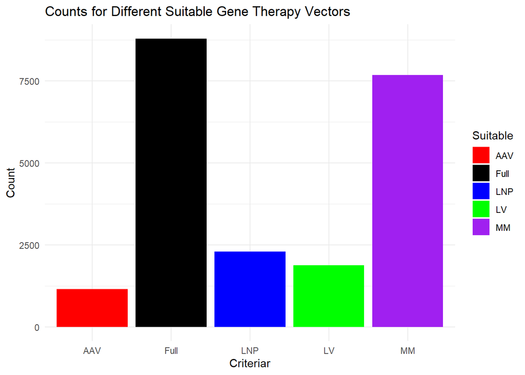

```r
#Liquid nanoparticle vectors typically can handle 8-10 kbp DNA inserts
omim3.gl.lnp <- omim3.gl %>%
    filter(Gene.Length < 10000) %>%
    arrange(Gene.Length)

#Lenti Viral vectors typically can handle 6-8 kbp DNA inserts
omim3.gl.lv <- omim3.gl %>%
    filter(Gene.Length < 8000) %>%
    arrange(Gene.Length)


#Table of genes that have mouse models
omim3.mm <- omim3[!trimws(omim3$Mouse.Gene.Symbol.ID) == "" & !is.na(omim3$Mouse.Gene.Symbol.ID), ]


#Tibble based on number of results filtered out for each criteria
omim.results <- tibble(
  Suitable = c("AAV", "LNP", "LV", "MM", "Full"),
  Count = c(1147, 2289, 1875, 7675, 8787)
)


#Graph to show how many genes are viable for gene therapy out of all collected genetic defects
omim.results.graph <- ggplot(omim.results, aes(x = Suitable, y = Count, fill = Suitable)) +
  geom_bar(stat = "identity") +
  theme_minimal() +
  labs(
    title = "Counts for Different Suitable Gene Therapy Vectors",
    x = "Criteriar",
    y = "Count"
  ) +
  scale_fill_manual(values = c("AAV" = "red", "LNP" = "blue", "LV" = "green", "MM" = "purple", "Full" = "black"))
omim.results.graph
```

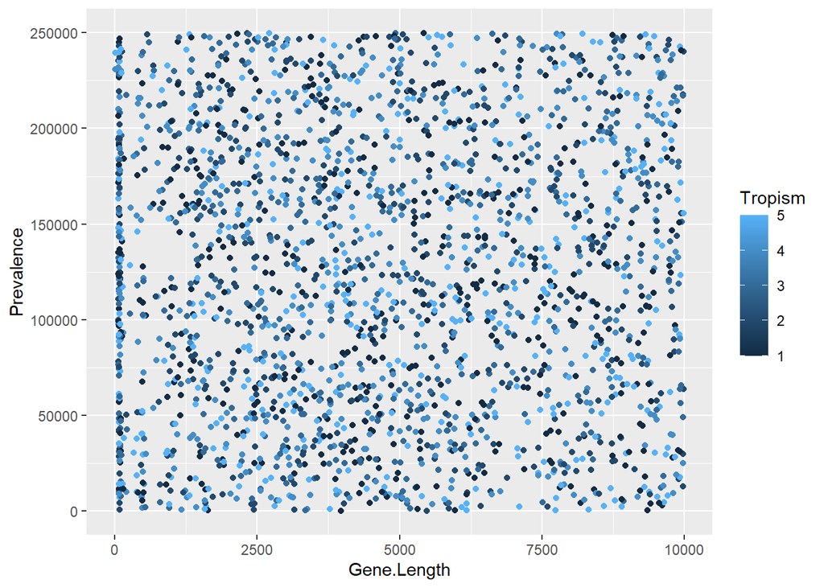

```r
#Due to a lack of databases, limited analysis could be performed. As an exercise, I decided to create a table with randomized data to simulate what future analysis could look like

#Adding a column for tropism, using 1=Liver, 2=Brain, 3=Heart, 4=Lung, 5=kidney

omim.test <- omim3.gl

omim.test$Tropism <- sample(1:5, nrow(omim.test), replace = TRUE)


#Adding another column to simulate disease prevalence in society

omim.test$Prevalence <- sample(1:250000, nrow(omim.test), replace = TRUE)


#To visualize if there are trends between gene size and these new variables, I created a scatter plot

ggplot(omim.test, aes(x=Gene.Length, y = Prevalence, color = Tropism)) +
  geom_point() +
  xlim(c(0, 10000)) #We mostly just need to focus on genes less than 10 kbs
```

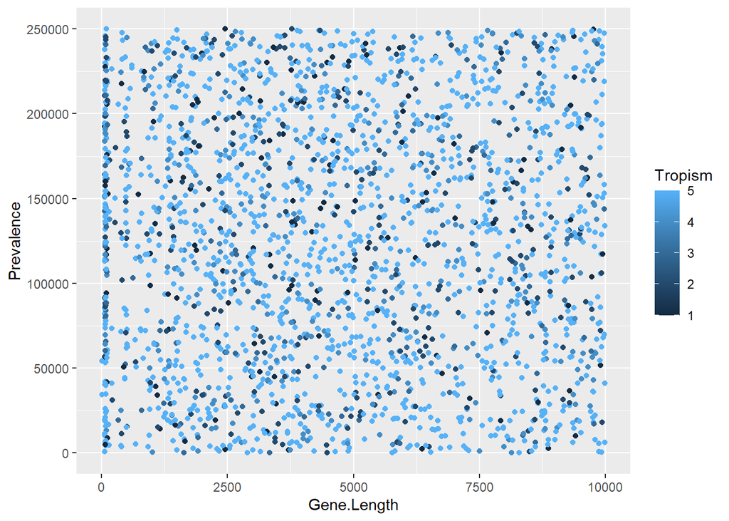

```r
#If tropism and prevalence is truly random, the above scatter plot is what we would expect. However  this project is being done in hopes of finding trends so I am going to force a trend into Tropism by creating an altered set of propabilities

Trop.weighted <- c(1,2,1,2,10) #create weighted probabilities

omim.weighted <- omim3.gl
omim.weighted$Tropism <- sample(1:5, nrow(omim.weighted), replace = TRUE, prob = Trop.weighted)
omim.weighted$Prevalence <- sample(1:250000, nrow(omim.weighted), replace = TRUE)


ggplot(omim.weighted, aes(x=Gene.Length, y = Prevalence, color = Tropism)) +
  geom_point() +
  xlim(c(0, 10000))
```

## 5 Conclusion

The biggest conclusion from this study was the reality that there is a lack of databases that exist publically with widespread data needed to support this type of analysis. Most databases seem tailored towards identification of the disease and phenotypes of the disease. Gene therapy is still a small field of medicine with only around 30 medications approved by the FDA currently, which is likely a reason for a lack of these databases.

In the future, databases that include disease tropism, prevalence, and viable animal models would be a huge asset. When you have a vector that works well, it’s likely to work well for other genes of similar size. So after sorting for a similar size, you also need to filter for tropism to make sure the gene selected will benefit from where it’s delivered to. Prevalence could help someone decide which diseases to work on if there are multiple suitable candidates in order to reach a wider audience. And if your vector only works in certain animal models, a database containing existing animal models for a disease would help select for other similar diseases.

Above, I attempted to simulate what the addition of a tropism and prevalence database would look like. Unfortunately the only viable way for me to do this was to randomly generate one. As seen in the first scatter plot, there doesn’t seem to be a trend between any of the characteristics, but as the data was random this was largely expected. And when I tried to weight the randomness of the generation, results were different, but the prevalence was still randomized. So while no trend was seen, it still shows that creation of tables like these from databases can still be useful.

For example, if I had a disease I had successfully implemented a cure for, I could then use this table to filter for genes euql to or less than the same gene length, filter for tropism, and sort by prevalence. This would give a top candidate that would likely have a high success rate if used.